# NFL 2025 Season Analysis

League Overview · Offense & Defense Tendencies · QB Profiles · Skill Positions

November 2026

# Team Pages

Click a team to view their full team report — pass rate tendencies, draft class, snap counts, trades, and free agent signings, styled in that team’s own colors.

ARI

ATL

BAL

BUF

CAR

CHI

CIN

CLE

DAL

DEN

DET

GB

HOU

IND

JAX

KC

LA

LAC

LV

MIA

MIN

NE

NO

NYG

NYJ

PHI

PIT

SEA

SF

TB

TEN

WAS

# Offense Tendencies

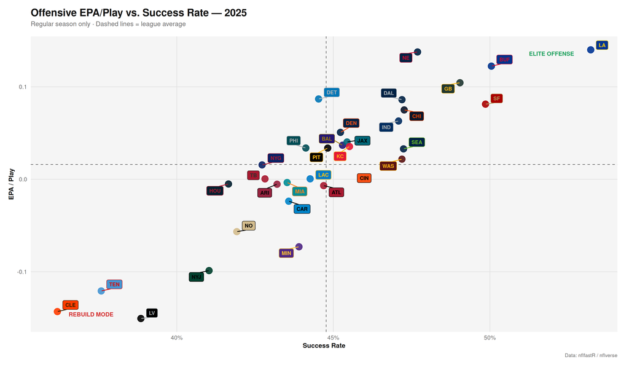

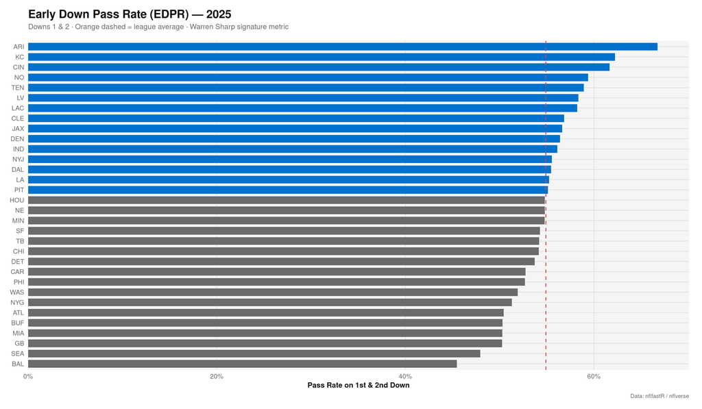

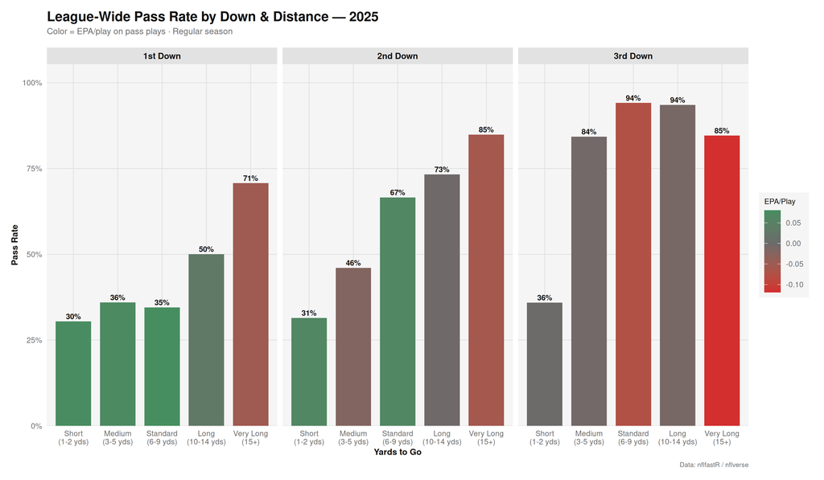

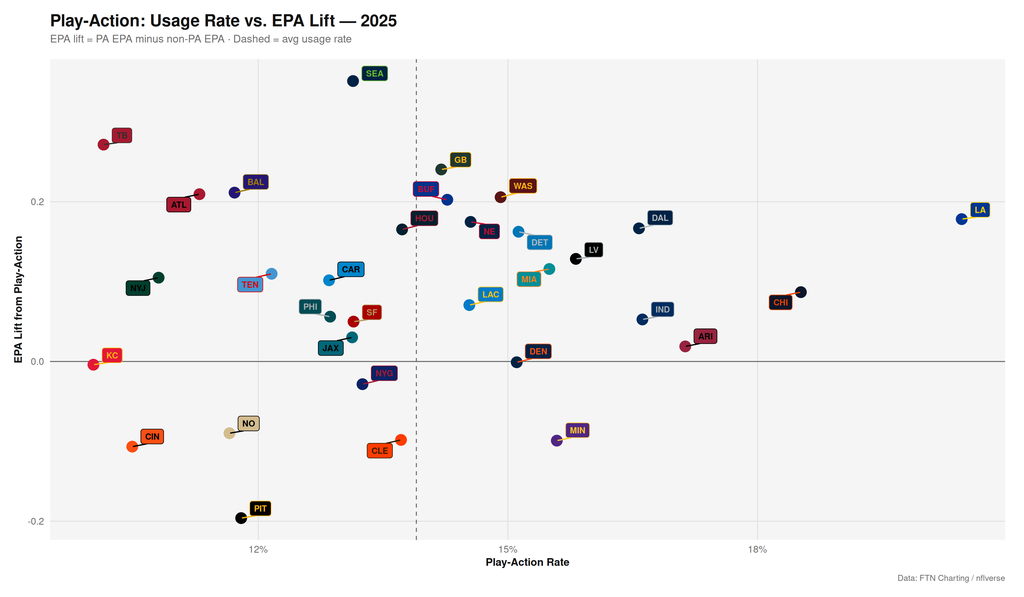

2025 Offensive Tendencies — All Teams

Team

EPA/Play

Success%

EDPR

Pass%

Air Yds

YAC

LA

0.14

53.2%

55.3%

59.1%

9.31

4.77

NE

0.14

47.7%

54.8%

60.4%

9.19

4.97

BUF

0.12

50.0%

50.3%

55.7%

7.32

5.91

GB

0.10

49.0%

50.3%

55.8%

8.78

5.08

DET

0.09

44.5%

53.7%

59.4%

6.44

6.12

DAL

0.09

47.2%

55.5%

62.0%

8.17

5.01

SF

0.08

49.9%

54.3%

59.1%

7.52

4.49

CHI

0.08

47.3%

54.1%

58.8%

8.65

5.54

IND

0.06

47.1%

56.1%

59.8%

8.04

5.02

DEN

0.05

45.2%

56.4%

62.7%

7.33

5.39

JAX

0.04

45.4%

56.6%

60.1%

8.71

4.78

BAL

0.04

45.3%

45.5%

52.6%

8.17

4.90

KC

0.04

45.5%

62.2%

65.8%

7.80

5.81

PHI

0.03

44.1%

52.7%

57.8%

9.06

4.29

PIT

0.03

44.8%

55.1%

60.8%

6.01

6.50

SEA

0.03

47.2%

47.9%

52.3%

7.89

5.52

WAS

0.02

47.2%

51.9%

58.0%

8.63

4.98

NYG

0.02

42.7%

51.3%

58.1%

8.52

5.47

CIN

0.00

45.9%

61.7%

65.9%

7.39

4.69

LAC

0.00

44.3%

58.2%

63.1%

8.05

4.80

TB

0.00

42.8%

54.2%

60.5%

8.09

5.63

MIA

0.00

43.5%

50.3%

56.6%

7.05

5.59

HOU

−0.01

41.7%

54.8%

60.2%

8.23

4.49

ARI

−0.01

43.2%

66.7%

69.6%

7.19

4.94

ATL

−0.01

44.7%

50.4%

56.6%

7.69

5.64

CAR

−0.02

43.6%

52.7%

58.7%

6.72

4.95

NO

−0.06

41.9%

59.4%

63.1%

8.18

4.28

MIN

−0.07

43.9%

54.8%

61.0%

7.78

5.14

NYJ

−0.10

41.0%

55.5%

60.8%

6.93

4.44

TEN

−0.12

37.6%

58.9%

64.9%

7.08

4.79

CLE

−0.14

36.2%

56.8%

62.4%

6.81

5.30

LV

−0.15

38.9%

58.4%

63.7%

6.27

5.31

# Defense Tendencies

[figure not shown]

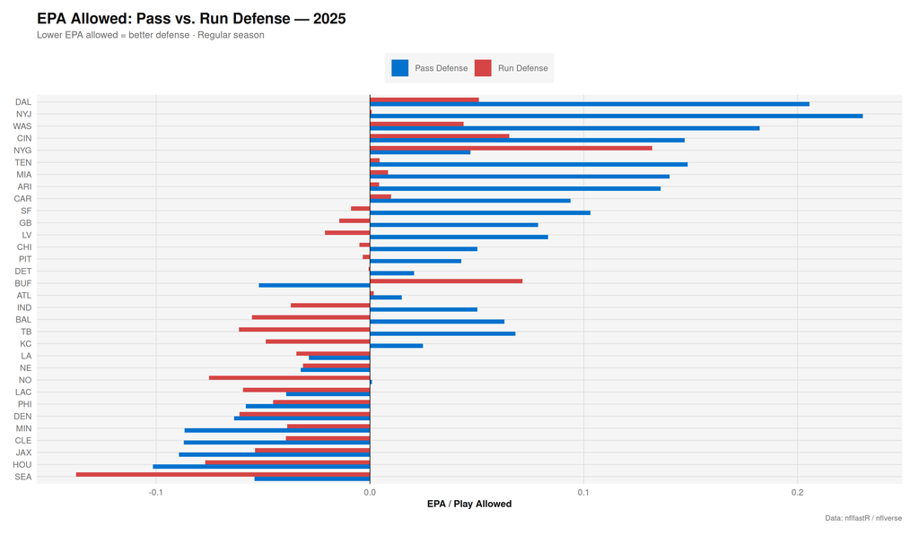

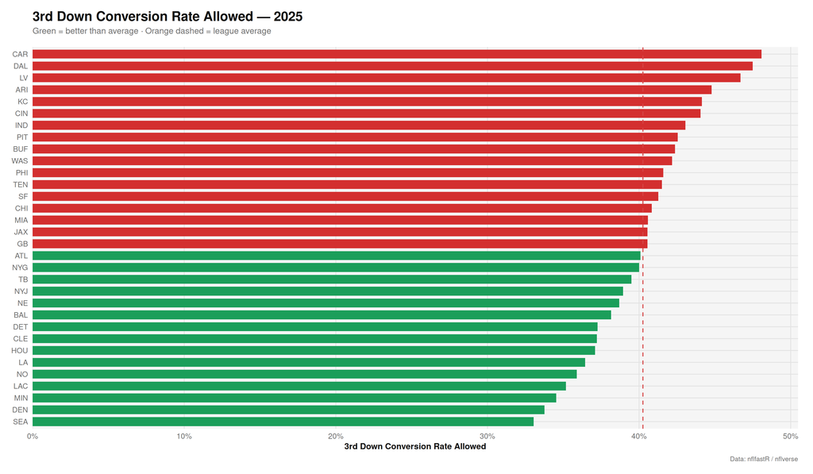

2025 Defensive Tendencies — All Teams

Team

EPA Allowed

Success% All

Pass EPA All

Run EPA All

3rd Conv All

HOU

−0.09

38.8%

−0.10

−0.08

37.1%

SEA

−0.08

40.2%

−0.05

−0.14

33.0%

JAX

−0.08

42.7%

−0.09

−0.05

40.6%

CLE

−0.07

40.2%

−0.09

−0.04

37.2%

MIN

−0.06

43.3%

−0.09

−0.04

34.5%

DEN

−0.06

38.1%

−0.06

−0.06

33.8%

PHI

−0.05

42.8%

−0.06

−0.05

41.6%

LAC

−0.05

42.4%

−0.04

−0.06

35.2%

NO

−0.03

42.4%

0.00

−0.08

35.9%

NE

−0.03

45.2%

−0.03

−0.03

38.7%

LA

−0.03

42.6%

−0.03

−0.03

36.4%

KC

0.00

44.8%

0.02

−0.05

44.1%

BUF

0.00

42.7%

−0.05

0.07

42.4%

ATL

0.01

45.7%

0.01

0.00

40.1%

DET

0.01

42.6%

0.02

0.00

37.3%

IND

0.02

46.3%

0.05

−0.04

43.1%

BAL

0.02

44.7%

0.06

−0.06

38.2%

TB

0.02

44.6%

0.07

−0.06

39.5%

PIT

0.03

44.6%

0.04

0.00

42.6%

CHI

0.03

47.7%

0.05

0.00

40.8%

LV

0.04

46.1%

0.08

−0.02

46.7%

GB

0.04

46.0%

0.08

−0.01

40.6%

CAR

0.06

45.4%

0.09

0.01

48.1%

SF

0.06

48.8%

0.10

−0.01

41.3%

NYG

0.08

48.0%

0.05

0.13

40.0%

ARI

0.08

49.1%

0.14

0.00

44.8%

MIA

0.09

49.8%

0.14

0.01

40.6%

TEN

0.09

46.0%

0.15

0.00

41.5%

CIN

0.11

48.0%

0.15

0.07

44.1%

WAS

0.12

48.2%

0.18

0.04

42.2%

NYJ

0.13

45.6%

0.23

0.00

38.9%

DAL

0.15

49.9%

0.21

0.05

47.5%

# QB Profiles

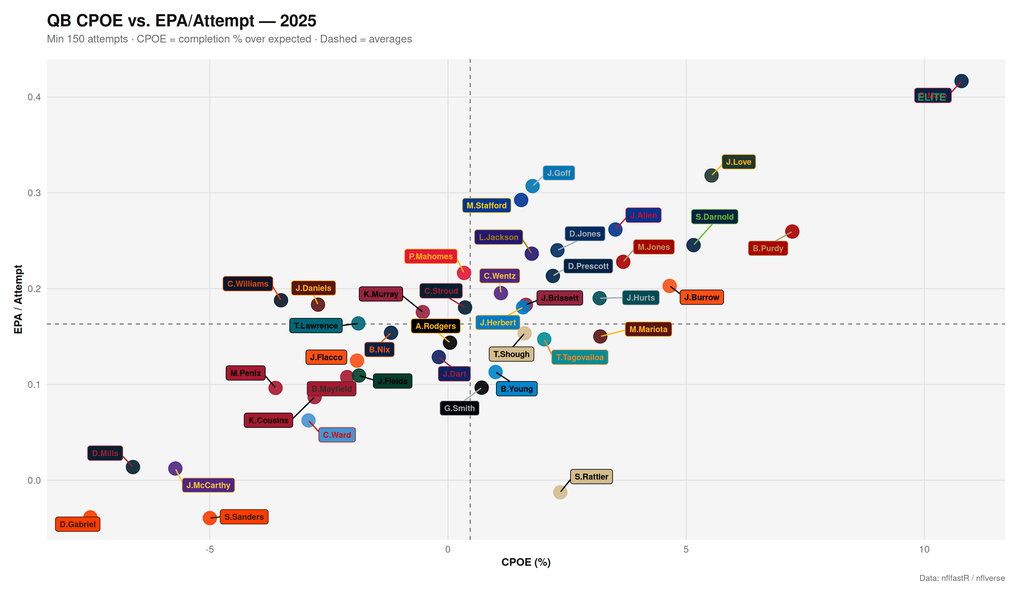

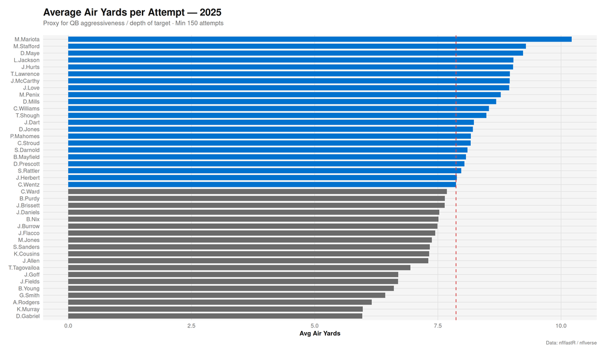

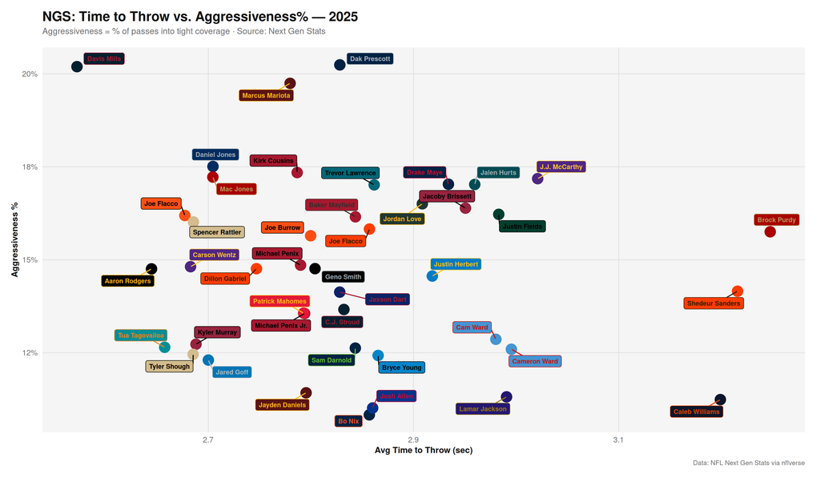

2025 QB Profiles — Qualified Passers (150+ Att)

QB

Team

Att

CPOE

EPA/Att

Air Yds

D.Maye

NE

472

10.78

0.42

9.23

J.Love

GB

411

5.53

0.32

8.95

J.Goff

DET

546

1.78

0.31

6.70

M.Stafford

LA

581

1.54

0.29

9.29

J.Allen

BUF

445

3.51

0.26

7.31

B.Purdy

SF

272

7.23

0.26

7.64

S.Darnold

SEA

451

5.16

0.25

8.10

D.Jones

IND

373

2.30

0.24

8.21

L.Jackson

BAL

290

1.76

0.24

9.03

M.Jones

SF

278

3.68

0.23

7.38

P.Mahomes

KC

473

0.34

0.22

8.17

D.Prescott

DAL

584

2.20

0.21

8.04

J.Burrow

CIN

248

4.65

0.20

7.49

C.Wentz

MIN

161

1.11

0.20

7.87

J.Hurts

PHI

427

3.18

0.19

9.03

C.Williams

CHI

526

−3.51

0.19

8.54

J.Daniels

WAS

174

−2.73

0.18

7.53

J.Brissett

ARI

457

1.64

0.18

7.64

J.Herbert

LAC

494

1.57

0.18

7.88

C.Stroud

HOU

401

0.36

0.18

8.17

K.Murray

ARI

157

−0.53

0.18

5.97

T.Lawrence

JAX

544

−1.88

0.16

8.96

B.Nix

DEN

583

−1.20

0.15

7.51

T.Shough

NO

315

1.61

0.15

8.49

M.Mariota

WAS

210

3.20

0.15

10.21

T.Tagovailoa

MIA

369

2.02

0.15

6.94

A.Rodgers

PIT

472

0.04

0.14

6.16

J.Dart

NYG

329

−0.19

0.13

8.23

J.Flacco

CIN

240

−1.91

0.12

7.45

B.Young

CAR

444

1.00

0.11

6.61

J.Fields

NYJ

194

−1.87

0.11

6.69

B.Mayfield

TB

527

−2.12

0.11

8.07

G.Smith

LV

428

0.71

0.10

6.43

M.Penix

ATL

264

−3.62

0.10

8.78

K.Cousins

ATL

255

−2.80

0.09

7.32

C.Ward

TEN

499

−2.93

0.06

7.68

D.Mills

HOU

152

−6.61

0.01

8.68

J.McCarthy

MIN

238

−5.72

0.01

8.96

S.Rattler

NO

245

2.36

−0.01

7.98

D.Gabriel

CLE

181

−7.51

−0.04

5.97

S.Sanders

CLE

195

−5.00

−0.04

7.34

# Skill Positions

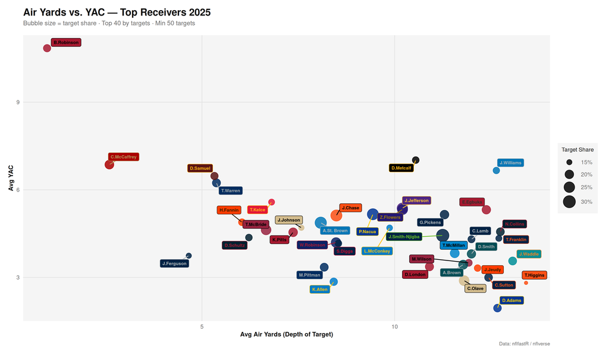

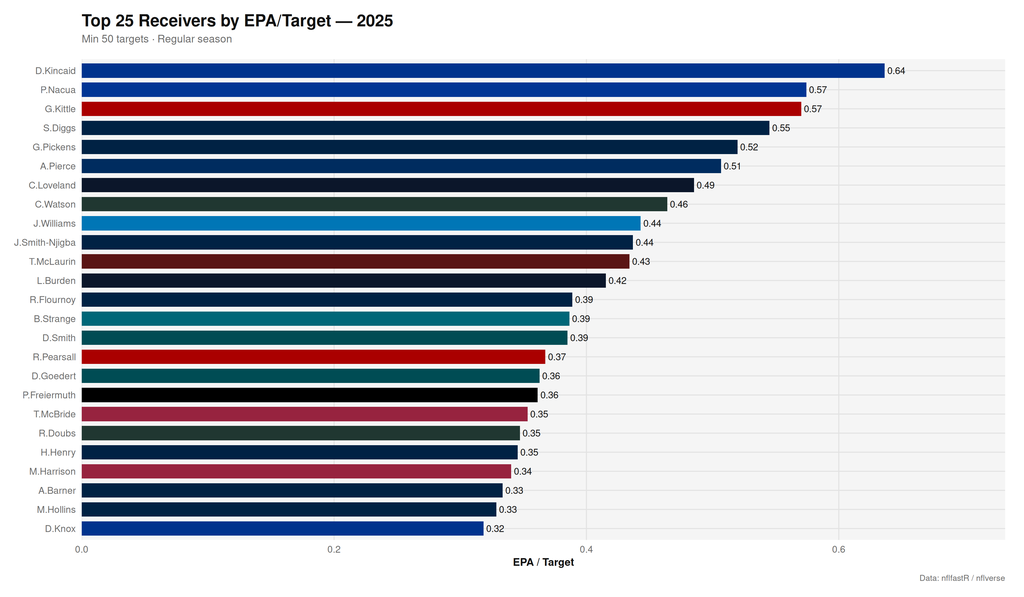

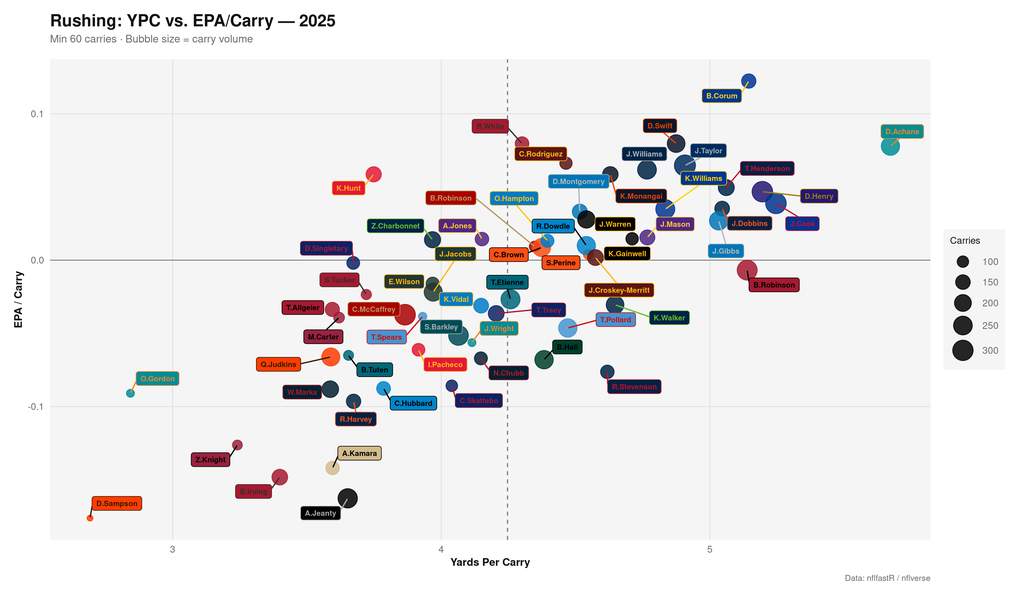

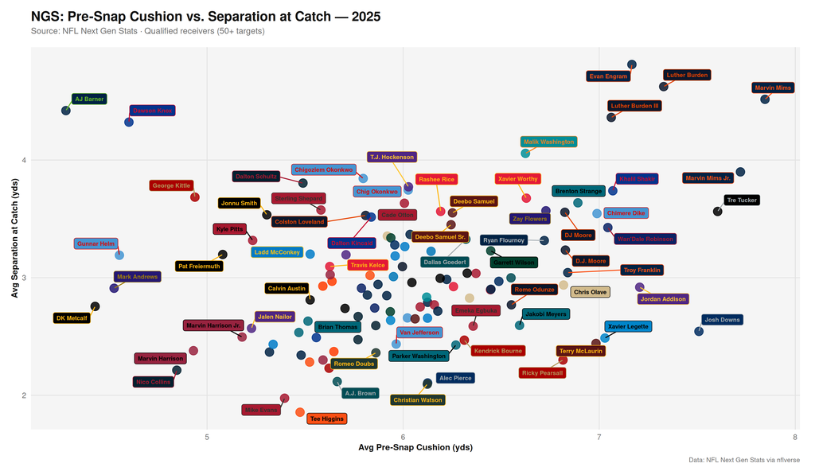

*Report generated 2026-11-28 18:15 · Data: nflfastR / nflreadr / nflverse · NGS: NFL Next Gen Stats*